# Automated surv report

[figure not shown]

[figure not shown]

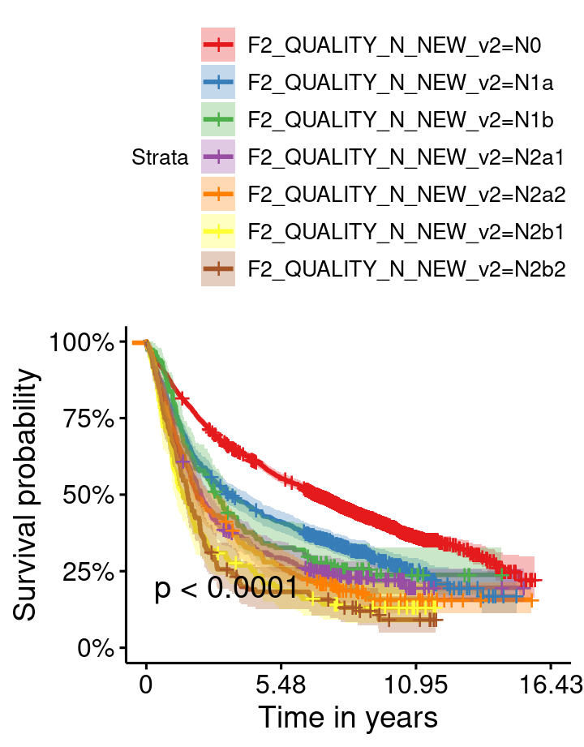

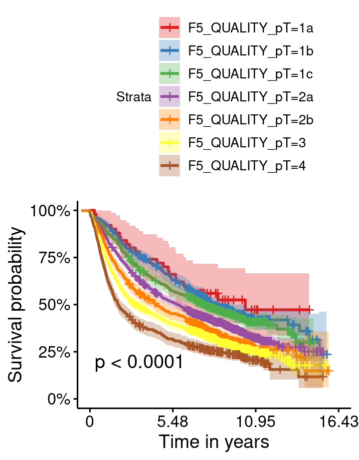

[figure not shown]

[figure not shown]

[figure not shown]

# Overall summary

|  | ST_4L_EXAMINED (N=659) | ST_4L_NOT_EXAMINED (N=4710) | pvalue | Overall (N=5369) |
| --- | --- | --- | --- | --- |
| P0_AGE |  |  |  |  |
| Mean (SD) | 62.4 (8.51) | 63.0 (8.33) | 0.167 | 62.9 (8.36) |
| Median [Min, Max] | 62.0 [38.0, 83.0] | 63.0 [22.0, 87.0] |  | 62.0 [22.0, 87.0] |
| P0b_SEX |  |  |  |  |
| Female | 170 (25.8%) | 1382 (29.3%) | 0.0666 | 1552 (28.9%) |
| Male | 489 (74.2%) | 3328 (70.7%) |  | 3817 (71.1%) |
| F5_STAGE |  |  |  |  |
|  | 0 (0%) | 1 (0.0%) | <0.001 | 1 (0.0%) |
| IA1 | 4 (0.6%) | 39 (0.8%) |  | 43 (0.8%) |
| IA2 | 51 (7.7%) | 411 (8.7%) |  | 462 (8.6%) |
| IA3 | 50 (7.6%) | 445 (9.4%) |  | 495 (9.2%) |
| IB | 125 (19.0%) | 1059 (22.5%) |  | 1184 (22.1%) |
| IIA | 43 (6.5%) | 386 (8.2%) |  | 429 (8.0%) |
| IIB | 159 (24.1%) | 1099 (23.3%) |  | 1258 (23.4%) |
| IIIA | 164 (24.9%) | 1007 (21.4%) |  | 1171 (21.8%) |
| IIIB | 63 (9.6%) | 263 (5.6%) |  | 326 (6.1%) |
| F1_SMOKING |  |  |  |  |
| NO | 202 (30.7%) | 1422 (30.2%) | 0.844 | 1624 (30.2%) |
| YES | 457 (69.3%) | 3288 (69.8%) |  | 3745 (69.8%) |
| F1_INSULIN_DEPENDENT_DIABETES |  |  |  |  |
| NO | 642 (97.4%) | 4526 (96.1%) | 0.116 | 5168 (96.3%) |
| YES | 17 (2.6%) | 184 (3.9%) |  | 201 (3.7%) |
| F1_CARDIAC_INFRACTION |  |  |  |  |
| NO | 621 (94.2%) | 4378 (93.0%) | 0.256 | 4999 (93.1%) |
| YES | 38 (5.8%) | 332 (7.0%) |  | 370 (6.9%) |
| F1_NERVOUS_SYSTEM_DISEASES |  |  |  |  |
| NO | 655 (99.4%) | 4657 (98.9%) | 0.311 | 5312 (98.9%) |
| YES | 4 (0.6%) | 53 (1.1%) |  | 57 (1.1%) |
| F1_ILLABILITY_OF_CIRCULATORY_SYSTEM |  |  |  |  |
| NO | 639 (97.0%) | 4588 (97.4%) | 0.591 | 5227 (97.4%) |
| YES | 20 (3.0%) | 122 (2.6%) |  | 142 (2.6%) |
| F1_KIDNEY_FAILURE |  |  |  |  |
| NO | 651 (98.8%) | 4681 (99.4%) | 0.137 | 5332 (99.3%) |
| YES | 8 (1.2%) | 29 (0.6%) |  | 37 (0.7%) |
| F1_COPD_CHRONIC_OBSTRUCTIVE_PULMONARY_DISEASE |  |  |  |  |
| NO | 446 (67.7%) | 3595 (76.3%) | <0.001 | 4041 (75.3%) |
| YES | 213 (32.3%) | 1115 (23.7%) |  | 1328 (24.7%) |
| F1_ARTERIAL_HYPERTENSION |  |  |  |  |
| NO | 410 (62.2%) | 2843 (60.4%) | 0.384 | 3253 (60.6%) |
| YES | 249 (37.8%) | 1867 (39.6%) |  | 2116 (39.4%) |
| F1_CORONARY_DISEASE |  |  |  |  |
| NO | 619 (93.9%) | 4398 (93.4%) | 0.649 | 5017 (93.4%) |
| YES | 40 (6.1%) | 312 (6.6%) |  | 352 (6.6%) |
| F5_QUALITY_pT |  |  |  |  |
| 1a | 5 (0.8%) | 45 (1.0%) | 0.346 | 50 (0.9%) |
| 1b | 61 (9.3%) | 503 (10.7%) |  | 564 (10.5%) |
| 1c | 74 (11.2%) | 563 (12.0%) |  | 637 (11.9%) |
| 2a | 200 (30.3%) | 1528 (32.4%) |  | 1728 (32.2%) |
| 2b | 90 (13.7%) | 627 (13.3%) |  | 717 (13.4%) |
| 3 | 140 (21.2%) | 934 (19.8%) |  | 1074 (20.0%) |
| 4 | 89 (13.5%) | 510 (10.8%) |  | 599 (11.2%) |
| F5_QUALITY_pN |  |  |  |  |
| 0 | 392 (59.5%) | 3217 (68.3%) | <0.001 | 3609 (67.2%) |
| 1 | 125 (19.0%) | 801 (17.0%) |  | 926 (17.2%) |
| 2 | 142 (21.5%) | 692 (14.7%) |  | 834 (15.5%) |
| F2_QUALITY_N_NEW_v2 |  |  |  |  |
| N0 | 392 (59.5%) | 3217 (68.3%) | <0.001 | 3609 (67.2%) |
| N1a | 98 (14.9%) | 681 (14.5%) |  | 779 (14.5%) |
| N1b | 27 (4.1%) | 120 (2.5%) |  | 147 (2.7%) |
| N2a1 | 43 (6.5%) | 274 (5.8%) |  | 317 (5.9%) |
| N2a2 | 36 (5.5%) | 223 (4.7%) |  | 259 (4.8%) |
| N2b1 | 34 (5.2%) | 92 (2.0%) |  | 126 (2.3%) |
| N2b2 | 29 (4.4%) | 103 (2.2%) |  | 132 (2.5%) |
| F4_EXTENT_OF_PULMONARY_RESECTION_TYPE |  |  |  |  |
| Lobectomy lower | 139 (21.1%) | 1515 (32.2%) | <0.001 | 1654 (30.8%) |
| Lobectomy upper | 267 (40.5%) | 2261 (48.0%) |  | 2528 (47.1%) |
| Pneumonectomy | 253 (38.4%) | 934 (19.8%) |  | 1187 (22.1%) |
| F4_SURGICAL_APPROACH |  |  |  |  |
| Thoracotomy | 651 (98.8%) | 4534 (96.3%) | 0.00128 | 5185 (96.6%) |
| VATS | 8 (1.2%) | 176 (3.7%) |  | 184 (3.4%) |
| F5_HISTOPATOLOGICAL_RECOGNITION |  |  |  |  |
| Adenocarcinoma | 273 (41.4%) | 2161 (45.9%) | 0.0349 | 2434 (45.3%) |
| Squamous cell carcinoma | 386 (58.6%) | 2549 (54.1%) |  | 2935 (54.7%) |
| F3_MEDIASTINOSCOPY |  |  |  |  |
| NO | 579 (87.9%) | 4267 (90.6%) | 0.0318 | 4846 (90.3%) |
| YES | 80 (12.1%) | 443 (9.4%) |  | 523 (9.7%) |

# ON_F5_N2_EXAMINED_ST_4L_LOWER_PARATRACHEAL_LEFT

### KM plot

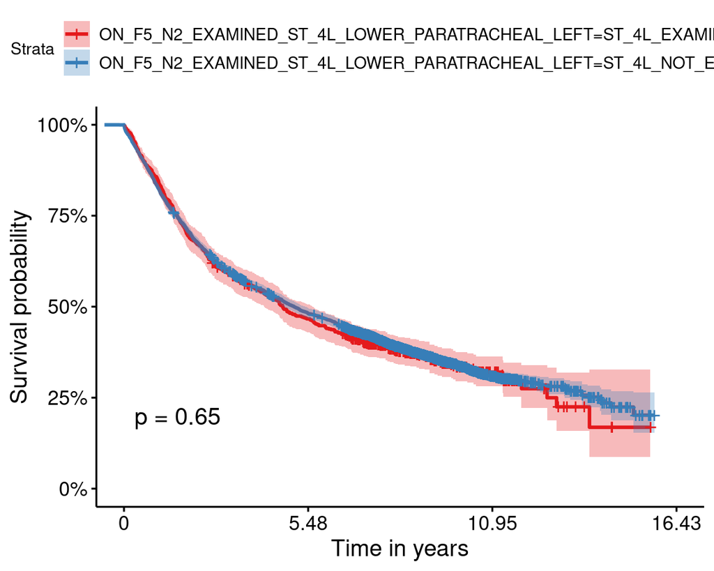

### summary table

| variable | cnt | 1826.25 days |
| --- | --- | --- |
| ON_F5_N2_EXAMINED_ST_4L_LOWER_PARATRACHEAL_LEFT=ST_4L_EXAMINED | 659 | 0.48 |
| ON_F5_N2_EXAMINED_ST_4L_LOWER_PARATRACHEAL_LEFT=ST_4L_NOT_EXAMINED | 4710 | 0.50 |

### Pairwise comparison

Values in table are p-values for each subset data between group 1 and group 2.

| subset | group1 | group2 | p.value |
| --- | --- | --- | --- |
| ALL | ST_4L_NOT_EXAMINED | ST_4L_EXAMINED | 0.652334 |

# F4_EXTENT_OF_PULMONARY_RESECTION_TYPE

### KM plot

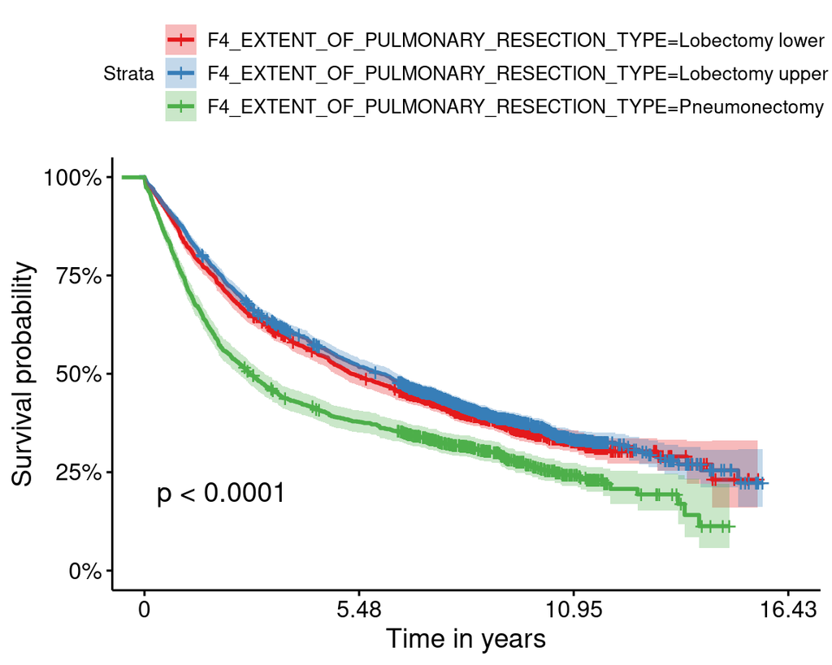

### summary table

| variable | cnt | 1826.25 days |
| --- | --- | --- |
| F4_EXTENT_OF_PULMONARY_RESECTION_TYPE=Lobectomy lower | 1654 | 0.52 |
| F4_EXTENT_OF_PULMONARY_RESECTION_TYPE=Lobectomy upper | 2528 | 0.54 |
| F4_EXTENT_OF_PULMONARY_RESECTION_TYPE=Pneumonectomy | 1187 | 0.39 |

### Pairwise comparison

Values in table are p-values for each subset data between group 1 and group 2.

| subset | group1 | group2 | p.value |
| --- | --- | --- | --- |
| ALL | Lobectomy upper | Lobectomy lower | 0.182434 |
| ALL | Pneumonectomy | Lobectomy lower | 0.000000 |
| ALL | Pneumonectomy | Lobectomy upper | 0.000000 |

# F2_QUALITY_N_NEW_v2

### KM plot

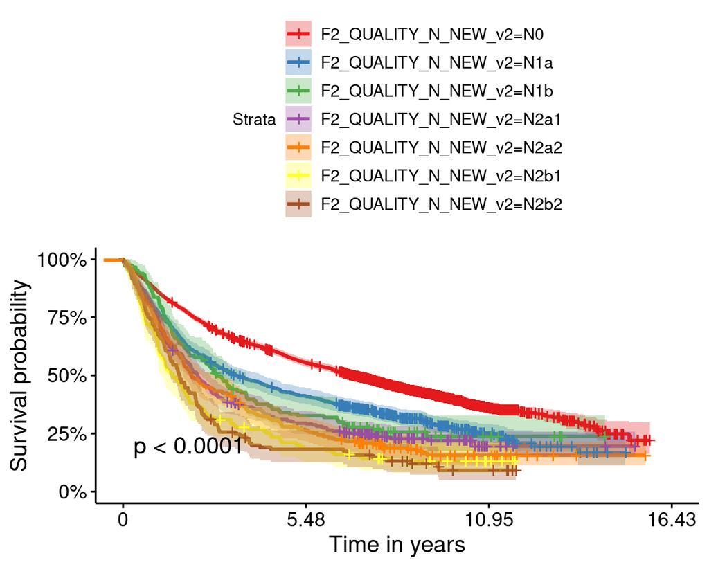

### summary table

| variable | cnt | 1826.25 days |
| --- | --- | --- |
| F2_QUALITY_N_NEW_v2=N0 | 3609 | 0.58 |
| F2_QUALITY_N_NEW_v2=N1a | 779 | 0.43 |
| F2_QUALITY_N_NEW_v2=N1b | 147 | 0.33 |
| F2_QUALITY_N_NEW_v2=N2a1 | 317 | 0.30 |
| F2_QUALITY_N_NEW_v2=N2a2 | 259 | 0.28 |
| F2_QUALITY_N_NEW_v2=N2b1 | 126 | 0.21 |
| F2_QUALITY_N_NEW_v2=N2b2 | 132 | 0.18 |

### Pairwise comparison

Values in table are p-values for each subset data between group 1 and group 2.

| subset | group1 | group2 | p.value |
| --- | --- | --- | --- |
| ALL | N1a | N0 | 0.0000000 |
| ALL | N1b | N0 | 0.0000002 |
| ALL | N1b | N1a | 0.3109258 |
| ALL | N2a1 | N0 | 0.0000000 |
| ALL | N2a1 | N1a | 0.0014310 |
| ALL | N2a1 | N1b | 0.2058871 |
| ALL | N2a2 | N0 | 0.0000000 |
| ALL | N2a2 | N1a | 0.0000856 |
| ALL | N2a2 | N1b | 0.0693635 |
| ALL | N2a2 | N2a1 | 0.4555675 |
| ALL | N2b1 | N0 | 0.0000000 |
| ALL | N2b1 | N1a | 0.0000003 |
| ALL | N2b1 | N1b | 0.0010340 |
| ALL | N2b1 | N2a1 | 0.0136157 |
| ALL | N2b1 | N2a2 | 0.0618991 |
| ALL | N2b2 | N0 | 0.0000000 |
| ALL | N2b2 | N1a | 0.0000000 |
| ALL | N2b2 | N1b | 0.0004371 |
| ALL | N2b2 | N2a1 | 0.0071506 |
| ALL | N2b2 | N2a2 | 0.0385360 |
| ALL | N2b2 | N2b1 | 0.9374754 |

# F5_QUALITY_pT

### KM plot

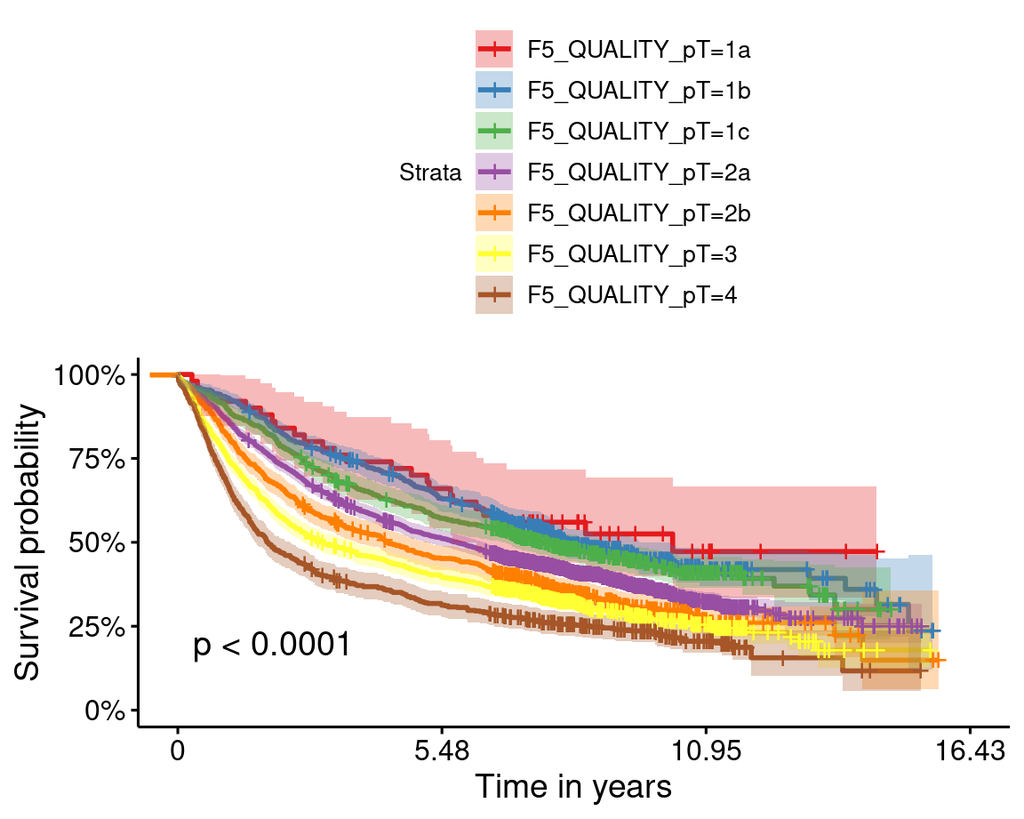

### summary table

| variable | cnt | 1826.25 days |
| --- | --- | --- |
| F5_QUALITY_pT=1a | 50 | 0.70 |
| F5_QUALITY_pT=1b | 564 | 0.66 |
| F5_QUALITY_pT=1c | 637 | 0.60 |
| F5_QUALITY_pT=2a | 1728 | 0.53 |
| F5_QUALITY_pT=2b | 717 | 0.47 |
| F5_QUALITY_pT=3 | 1074 | 0.41 |
| F5_QUALITY_pT=4 | 599 | 0.33 |

### Pairwise comparison

Values in table are p-values for each subset data between group 1 and group 2.

| subset | group1 | group2 | p.value |
| --- | --- | --- | --- |
| ALL | 1b | 1a | 0.5598285 |
| ALL | 1c | 1a | 0.2826769 |
| ALL | 1c | 1b | 0.1670208 |
| ALL | 2a | 1a | 0.0391085 |
| ALL | 2a | 1b | 0.0000030 |
| ALL | 2a | 1c | 0.0010750 |
| ALL | 2b | 1a | 0.0043062 |
| ALL | 2b | 1b | 0.0000000 |
| ALL | 2b | 1c | 0.0000001 |
| ALL | 2b | 2a | 0.0016393 |
| ALL | 3 | 1a | 0.0006818 |
| ALL | 3 | 1b | 0.0000000 |
| ALL | 3 | 1c | 0.0000000 |
| ALL | 3 | 2a | 0.0000000 |
| ALL | 3 | 2b | 0.0203227 |
| ALL | 4 | 1a | 0.0000109 |
| ALL | 4 | 1b | 0.0000000 |
| ALL | 4 | 1c | 0.0000000 |
| ALL | 4 | 2a | 0.0000000 |
| ALL | 4 | 2b | 0.0000000 |
| ALL | 4 | 3 | 0.0002583 |

# ON_F5_N2_CLASS_EXAMINED_INVOLVED_ST_4L

### KM plot

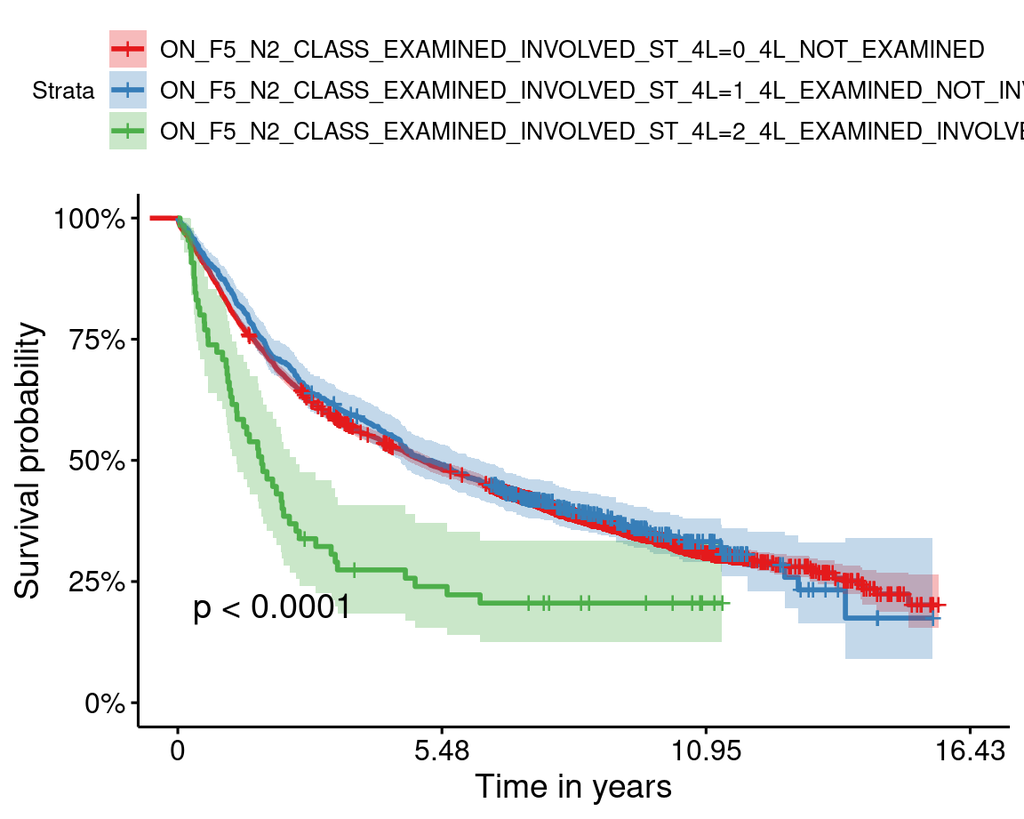

### summary table

| variable | cnt | 1826.25 days |
| --- | --- | --- |
| ON_F5_N2_CLASS_EXAMINED_INVOLVED_ST_4L=0_4L_NOT_EXAMINED | 4710 | 0.50 |
| ON_F5_N2_CLASS_EXAMINED_INVOLVED_ST_4L=1_4L_EXAMINED_NOT_INVOLVED | 594 | 0.51 |
| ON_F5_N2_CLASS_EXAMINED_INVOLVED_ST_4L=2_4L_EXAMINED_INVOLVED | 65 | 0.24 |

### Pairwise comparison

Values in table are p-values for each subset data between group 1 and group 2.

| subset | group1 | group2 | p.value |
| --- | --- | --- | --- |
| ALL | 1_4L_EXAMINED_NOT_INVOLVED | 0_4L_NOT_EXAMINED | 0.5046311 |
| ALL | 2_4L_EXAMINED_INVOLVED | 0_4L_NOT_EXAMINED | 0.0000105 |
| ALL | 2_4L_EXAMINED_INVOLVED | 1_4L_EXAMINED_NOT_INVOLVED | 0.0000086 |

# Var: ON_F5_N2_CLASS_EXAMINED_INVOLVED_ST_4L Group: F2_QUALITY_N_NEW_v2

### Table

| group | 1826.25 days_ON_F5_N2_CLASS_EXAMINED_INVOLVED_ST_4L=0_4L_NOT_EXAMINED | 1826.25 days_ON_F5_N2_CLASS_EXAMINED_INVOLVED_ST_4L=1_4L_EXAMINED_NOT_INVOLVED | 1826.25 days_ON_F5_N2_CLASS_EXAMINED_INVOLVED_ST_4L=2_4L_EXAMINED_INVOLVED | cnt | pval.txt |
| --- | --- | --- | --- | --- | --- |
| N0 | 0.58 | 0.57 | NA | 3217-392-0 | p = 0.92 |
| N1a | 0.42 | 0.46 | NA | 681-98-0 | p = 0.25 |
| N1b | 0.33 | 0.36 | NA | 120-27-0 | p = 0.39 |
| N2a1 | 0.29 | 0.34 | 0.62 | 274-35-8 | p = 0.091 |
| N2a2 | 0.27 | 0.35 | 0.31 | 223-23-13 | p = 0.44 |
| N2b1 | 0.20 | 0.33 | 0.18 | 92-12-22 | p = 0.56 |
| N2b2 | 0.21 | 0.00 | 0.12 | 103-7-22 | p = 0.26 |

### Pairwise comparison

Values in table are p-values for each subset data between group 1 and group 2.

| subset | group1 | group2 | p.value |
| --- | --- | --- | --- |
| F2_QUALITY_N_NEW_v2:N0 | 1_4L_EXAMINED_NOT_INVOLVED | 0_4L_NOT_EXAMINED | 0.9195538 |
| F2_QUALITY_N_NEW_v2:N1a | 1_4L_EXAMINED_NOT_INVOLVED | 0_4L_NOT_EXAMINED | 0.2484834 |
| F2_QUALITY_N_NEW_v2:N1b | 1_4L_EXAMINED_NOT_INVOLVED | 0_4L_NOT_EXAMINED | 0.3880415 |
| F2_QUALITY_N_NEW_v2:N2a1 | 1_4L_EXAMINED_NOT_INVOLVED | 0_4L_NOT_EXAMINED | 0.6874048 |
| F2_QUALITY_N_NEW_v2:N2a1 | 2_4L_EXAMINED_INVOLVED | 0_4L_NOT_EXAMINED | 0.0542996 |
| F2_QUALITY_N_NEW_v2:N2a1 | 2_4L_EXAMINED_INVOLVED | 1_4L_EXAMINED_NOT_INVOLVED | 0.0542996 |
| F2_QUALITY_N_NEW_v2:N2a2 | 1_4L_EXAMINED_NOT_INVOLVED | 0_4L_NOT_EXAMINED | 0.5844229 |
| F2_QUALITY_N_NEW_v2:N2a2 | 2_4L_EXAMINED_INVOLVED | 0_4L_NOT_EXAMINED | 0.8604270 |
| F2_QUALITY_N_NEW_v2:N2a2 | 2_4L_EXAMINED_INVOLVED | 1_4L_EXAMINED_NOT_INVOLVED | 0.7720562 |
| F2_QUALITY_N_NEW_v2:N2b1 | 1_4L_EXAMINED_NOT_INVOLVED | 0_4L_NOT_EXAMINED | 0.4874360 |
| F2_QUALITY_N_NEW_v2:N2b1 | 2_4L_EXAMINED_INVOLVED | 0_4L_NOT_EXAMINED | 0.7855664 |
| F2_QUALITY_N_NEW_v2:N2b1 | 2_4L_EXAMINED_INVOLVED | 1_4L_EXAMINED_NOT_INVOLVED | 0.4874360 |
| F2_QUALITY_N_NEW_v2:N2b2 | 1_4L_EXAMINED_NOT_INVOLVED | 0_4L_NOT_EXAMINED | 0.3882114 |
| F2_QUALITY_N_NEW_v2:N2b2 | 2_4L_EXAMINED_INVOLVED | 0_4L_NOT_EXAMINED | 0.3882114 |
| F2_QUALITY_N_NEW_v2:N2b2 | 2_4L_EXAMINED_INVOLVED | 1_4L_EXAMINED_NOT_INVOLVED | 0.6434387 |

# Var: ON_F5_N2_EXAMINED_ST_4L_LOWER_PARATRACHEAL_LEFT Group: F2_QUALITY_N_NEW_v2

### Table

| group | 1826.25 days_ON_F5_N2_EXAMINED_ST_4L_LOWER_PARATRACHEAL_LEFT=ST_4L_EXAMINED | 1826.25 days_ON_F5_N2_EXAMINED_ST_4L_LOWER_PARATRACHEAL_LEFT=ST_4L_NOT_EXAMINED | cnt | pval.txt |
| --- | --- | --- | --- | --- |
| N0 | 0.57 | 0.58 | 392-3217 | p = 0.92 |
| N1a | 0.46 | 0.42 | 98-681 | p = 0.25 |
| N1b | 0.36 | 0.33 | 27-120 | p = 0.39 |
| N2a1 | 0.39 | 0.29 | 43-274 | p = 0.48 |
| N2a2 | 0.33 | 0.27 | 36-223 | p = 0.26 |
| N2b1 | 0.24 | 0.20 | 34-92 | p = 0.72 |
| N2b2 | 0.06 | 0.21 | 29-103 | p = 0.12 |

### Pairwise comparison

Values in table are p-values for each subset data between group 1 and group 2.

| subset | group1 | group2 | p.value |
| --- | --- | --- | --- |
| F2_QUALITY_N_NEW_v2:N0 | ST_4L_NOT_EXAMINED | ST_4L_EXAMINED | 0.9195538 |
| F2_QUALITY_N_NEW_v2:N1a | ST_4L_NOT_EXAMINED | ST_4L_EXAMINED | 0.2484834 |
| F2_QUALITY_N_NEW_v2:N1b | ST_4L_NOT_EXAMINED | ST_4L_EXAMINED | 0.3880415 |
| F2_QUALITY_N_NEW_v2:N2a1 | ST_4L_NOT_EXAMINED | ST_4L_EXAMINED | 0.4805048 |
| F2_QUALITY_N_NEW_v2:N2a2 | ST_4L_NOT_EXAMINED | ST_4L_EXAMINED | 0.2572436 |
| F2_QUALITY_N_NEW_v2:N2b1 | ST_4L_NOT_EXAMINED | ST_4L_EXAMINED | 0.7151452 |
| F2_QUALITY_N_NEW_v2:N2b2 | ST_4L_NOT_EXAMINED | ST_4L_EXAMINED | 0.1217876 |

# Univariate Cox model

## pvalue - univariate Cox

|  | all |
| --- | --- |
| P0_AGE | 5.863089e-31 |
| P0b_SEX | 9.478243e-14 |
| F5_STAGE | 3.098268e-95 |
| F1_SMOKING | 0.4298185 |
| F1_INSULIN_DEPENDENT_DIABETES | 0.02070969 |
| F1_CARDIAC_INFRACTION | 0.001867553 |
| F1_NERVOUS_SYSTEM_DISEASES | 0.9371013 |
| F1_ILLABILITY_OF_CIRCULATORY_SYSTEM | 4.193985e-06 |
| F1_KIDNEY_FAILURE | 0.004335134 |
| F1_COPD_CHRONIC_OBSTRUCTIVE_PULMONARY_DISEASE | 0.02291686 |
| F1_ARTERIAL_HYPERTENSION | 0.520179 |
| F1_CORONARY_DISEASE | 0.1745204 |
| F5_QUALITY_pT | 5.132524e-46 |
| F5_QUALITY_pN | 1.306357e-67 |
| F2_QUALITY_N_NEW_v2 | 1.337323e-66 |
| F4_EXTENT_OF_PULMONARY_RESECTION_TYPE | 3.023258e-18 |
| F4_SURGICAL_APPROACH | 1.399053e-05 |
| F5_HISTOPATOLOGICAL_RECOGNITION | 0.1224248 |
| ON_F5_N2_EXAMINED_ST_4L_LOWER_PARATRACHEAL_LEFT | 0.6533988 |
| F3_MEDIASTINOSCOPY | 0.6618663 |

## significant variable

| x |
| --- |
| P0_AGE |
| P0b_SEX |
| F5_STAGE |
| F1_INSULIN_DEPENDENT_DIABETES |
| F1_CARDIAC_INFRACTION |
| F1_ILLABILITY_OF_CIRCULATORY_SYSTEM |
| F1_KIDNEY_FAILURE |
| F1_COPD_CHRONIC_OBSTRUCTIVE_PULMONARY_DISEASE |
| F5_QUALITY_pT |
| F5_QUALITY_pN |
| F2_QUALITY_N_NEW_v2 |
| F4_EXTENT_OF_PULMONARY_RESECTION_TYPE |
| F4_SURGICAL_APPROACH |

# Multivariate Cox model

| term | estimate | std.error | statistic | p.value |
| --- | --- | --- | --- | --- |
| F4_EXTENT_OF_PULMONARY_RESECTION_TYPELobectomy upper | 1.015867e+00 | 0.0407511 | 0.3863081 | 0.6992685 |
| F4_EXTENT_OF_PULMONARY_RESECTION_TYPEPneumonectomy | 1.211168e+00 | 0.0493011 | 3.8860269 | 0.0001019 |
| F2_QUALITY_N_NEW_v2N1a | 1.127463e+00 | 0.1057434 | 1.1345339 | 0.2565706 |
| F2_QUALITY_N_NEW_v2N1b | 1.323855e+00 | 0.1354899 | 2.0706194 | 0.0383944 |
| F2_QUALITY_N_NEW_v2N2a1 | 1.391134e+00 | 0.2255013 | 1.4639351 | 0.1432117 |
| F2_QUALITY_N_NEW_v2N2a2 | 1.509113e+00 | 0.2273853 | 1.8098009 | 0.0703267 |
| F2_QUALITY_N_NEW_v2N2b1 | 1.883359e+00 | 0.2392077 | 2.6464733 | 0.0081336 |
| F2_QUALITY_N_NEW_v2N2b2 | 2.098017e+00 | 0.2309775 | 3.2080730 | 0.0013363 |
| F5_QUALITY_pT1b | 8.906567e-01 | 0.4641456 | -0.2494825 | 0.8029876 |
| F5_QUALITY_pT1c | 7.438940e-01 | 0.4606222 | -0.6422980 | 0.5206797 |
| F5_QUALITY_pT2a | 8.528474e-01 | 0.4518257 | -0.3522922 | 0.7246192 |
| F5_QUALITY_pT2b | 9.297404e-01 | 0.4543537 | -0.1603374 | 0.8726153 |
| F5_QUALITY_pT3 | 9.520425e-01 | 0.4627244 | -0.1062093 | 0.9154163 |
| F5_QUALITY_pT4 | 1.025002e+00 | 0.4804998 | 0.0513926 | 0.9590127 |
| ON_F5_N2_CLASS_EXAMINED_INVOLVED_ST_4L1_4L_EXAMINED_NOT_INVOLVED | 9.115639e-01 | 0.0556729 | -1.6631718 | 0.0962780 |
| ON_F5_N2_CLASS_EXAMINED_INVOLVED_ST_4L2_4L_EXAMINED_INVOLVED | 9.210870e-01 | 0.1487251 | -0.5527031 | 0.5804667 |
| P0_AGE | 1.025611e+00 | 0.0021490 | 11.7675073 | 0.0000000 |
| P0b_SEXMale | 1.196073e+00 | 0.0404960 | 4.4212767 | 0.0000098 |
| F5_STAGEIA1 | 4.034391e+04 | 283.7814944 | 0.0373710 | 0.9701892 |
| F5_STAGEIA2 | 4.817217e+04 | 283.7817894 | 0.0379959 | 0.9696910 |
| F5_STAGEIA3 | 6.390952e+04 | 283.7817821 | 0.0389920 | 0.9688968 |
| F5_STAGEIB | 6.359874e+04 | 283.7817629 | 0.0389748 | 0.9689104 |
| F5_STAGEIIA | 6.430491e+04 | 283.7817708 | 0.0390138 | 0.9688794 |
| F5_STAGEIIB | 7.730685e+04 | 283.7817358 | 0.0396627 | 0.9683621 |
| F5_STAGEIIIA | 9.217737e+04 | 283.7817610 | 0.0402826 | 0.9678678 |
| F5_STAGEIIIB | 8.493179e+04 | 283.7818622 | 0.0399941 | 0.9680978 |
| F1_INSULIN_DEPENDENT_DIABETESYES | 1.107165e+00 | 0.0864036 | 1.1782197 | 0.2387090 |
| F1_CARDIAC_INFRACTIONYES | 1.069746e+00 | 0.0654966 | 1.0293850 | 0.3032988 |
| F1_ILLABILITY_OF_CIRCULATORY_SYSTEMYES | 1.413814e+00 | 0.0993389 | 3.4859575 | 0.0004904 |
| F1_KIDNEY_FAILUREYES | 1.692732e+00 | 0.1803602 | 2.9182936 | 0.0035195 |
| F1_COPD_CHRONIC_OBSTRUCTIVE_PULMONARY_DISEASEYES | 1.037308e+00 | 0.0399790 | 0.9162021 | 0.3595609 |
| F4_SURGICAL_APPROACHVATS | 8.169526e-01 | 0.1111542 | -1.8188629 | 0.0689323 |

# Multivariate Cox model - grouped

### F2_QUALITY_N_NEW_v2:N0

| term | estimate | std.error | statistic | p.value |
| --- | --- | --- | --- | --- |
| F4_EXTENT_OF_PULMONARY_RESECTION_TYPELobectomy upper | 1.0360050 | 0.0497403 | 0.7111327 | 0.4770020 |
| F4_EXTENT_OF_PULMONARY_RESECTION_TYPEPneumonectomy | 1.2057294 | 0.0685990 | 2.7272222 | 0.0063870 |
| F2_QUALITY_N_NEW_v2N1a | NA | 0.0000000 | NA | NA |
| F2_QUALITY_N_NEW_v2N1b | NA | 0.0000000 | NA | NA |
| F2_QUALITY_N_NEW_v2N2a1 | NA | 0.0000000 | NA | NA |
| F2_QUALITY_N_NEW_v2N2a2 | NA | 0.0000000 | NA | NA |
| F2_QUALITY_N_NEW_v2N2b1 | NA | 0.0000000 | NA | NA |
| F2_QUALITY_N_NEW_v2N2b2 | NA | 0.0000000 | NA | NA |
| F5_QUALITY_pT1b | 1.0655736 | 0.2397803 | 0.2648811 | 0.7911010 |
| F5_QUALITY_pT1c | 1.1755280 | 0.2386532 | 0.6776253 | 0.4980093 |
| F5_QUALITY_pT2a | 1.3428607 | 0.2333209 | 1.2635054 | 0.2064076 |
| F5_QUALITY_pT2b | 1.4705181 | 0.2383798 | 1.6176489 | 0.1057383 |
| F5_QUALITY_pT3 | 1.8154662 | 0.2350246 | 2.5373614 | 0.0111692 |
| F5_QUALITY_pT4 | 2.3430365 | 0.2400462 | 3.5470164 | 0.0003896 |
| ON_F5_N2_CLASS_EXAMINED_INVOLVED_ST_4L1_4L_EXAMINED_NOT_INVOLVED | 0.9503525 | 0.0712793 | -0.7144044 | 0.4749772 |
| ON_F5_N2_CLASS_EXAMINED_INVOLVED_ST_4L2_4L_EXAMINED_INVOLVED | NA | 0.0000000 | NA | NA |
| P0_AGE | 1.0292063 | 0.0027503 | 10.4672773 | 0.0000000 |
| P0b_SEXMale | 1.2798389 | 0.0521005 | 4.7357340 | 0.0000022 |
| F5_STAGEIA1 | NA | 0.0000000 | NA | NA |
| F5_STAGEIA2 | NA | 0.0000000 | NA | NA |
| F5_STAGEIA3 | NA | 0.0000000 | NA | NA |
| F5_STAGEIB | NA | 0.0000000 | NA | NA |
| F5_STAGEIIA | NA | 0.0000000 | NA | NA |
| F5_STAGEIIB | NA | 0.0000000 | NA | NA |
| F5_STAGEIIIA | NA | 0.0000000 | NA | NA |
| F5_STAGEIIIB | NA | 0.0000000 | NA | NA |
| F1_INSULIN_DEPENDENT_DIABETESYES | 1.0674920 | 0.1144609 | 0.5706051 | 0.5682674 |
| F1_CARDIAC_INFRACTIONYES | 1.0992297 | 0.0818824 | 1.1554333 | 0.2479130 |
| F1_ILLABILITY_OF_CIRCULATORY_SYSTEMYES | 1.2785370 | 0.1280278 | 1.9192425 | 0.0549537 |
| F1_KIDNEY_FAILUREYES | 1.7081965 | 0.2170099 | 2.4673446 | 0.0136119 |
| F1_COPD_CHRONIC_OBSTRUCTIVE_PULMONARY_DISEASEYES | 1.0486639 | 0.0512624 | 0.9269353 | 0.3539601 |
| F4_SURGICAL_APPROACHVATS | 0.8029156 | 0.1314032 | -1.6704750 | 0.0948254 |

### F2_QUALITY_N_NEW_v2:N1a

| term | estimate | std.error | statistic | p.value |
| --- | --- | --- | --- | --- |
| F4_EXTENT_OF_PULMONARY_RESECTION_TYPELobectomy upper | 1.094037e+00 | 0.1090413 | 0.8242220 | 0.4098134 |
| F4_EXTENT_OF_PULMONARY_RESECTION_TYPEPneumonectomy | 1.134334e+00 | 0.1118447 | 1.1269683 | 0.2597559 |
| F2_QUALITY_N_NEW_v2N1a | NA | 0.0000000 | NA | NA |
| F2_QUALITY_N_NEW_v2N1b | NA | 0.0000000 | NA | NA |
| F2_QUALITY_N_NEW_v2N2a1 | NA | 0.0000000 | NA | NA |
| F2_QUALITY_N_NEW_v2N2a2 | NA | 0.0000000 | NA | NA |
| F2_QUALITY_N_NEW_v2N2b1 | NA | 0.0000000 | NA | NA |
| F2_QUALITY_N_NEW_v2N2b2 | NA | 0.0000000 | NA | NA |
| F5_QUALITY_pT1b | 1.362179e+00 | 0.7366199 | 0.4195996 | 0.6747780 |
| F5_QUALITY_pT1c | 1.458398e+00 | 0.7267643 | 0.5192038 | 0.6036186 |
| F5_QUALITY_pT2a | 1.568081e+00 | 0.7170994 | 0.6273226 | 0.5304478 |
| F5_QUALITY_pT2b | 1.485927e+00 | 0.7230127 | 0.5477623 | 0.5838552 |
| F5_QUALITY_pT3 | 1.458693e+06 | 1120.5428840 | 0.0126662 | 0.9898941 |
| F5_QUALITY_pT4 | 1.599994e+06 | 1120.5428856 | 0.0127487 | 0.9898283 |
| ON_F5_N2_CLASS_EXAMINED_INVOLVED_ST_4L1_4L_EXAMINED_NOT_INVOLVED | 8.632498e-01 | 0.1337775 | -1.0992221 | 0.2716712 |
| ON_F5_N2_CLASS_EXAMINED_INVOLVED_ST_4L2_4L_EXAMINED_INVOLVED | NA | 0.0000000 | NA | NA |
| P0_AGE | 1.018173e+00 | 0.0056019 | 3.2149584 | 0.0013046 |
| P0b_SEXMale | 1.201445e+00 | 0.1069317 | 1.7162818 | 0.0861105 |
| F5_STAGEIA1 | NA | 0.0000000 | NA | NA |
| F5_STAGEIA2 | NA | 0.0000000 | NA | NA |
| F5_STAGEIA3 | NA | 0.0000000 | NA | NA |
| F5_STAGEIB | NA | 0.0000000 | NA | NA |
| F5_STAGEIIA | NA | 0.0000000 | NA | NA |
| F5_STAGEIIB | 7.528819e+05 | 1120.5431052 | 0.0120760 | 0.9903650 |
| F5_STAGEIIIA | NA | 0.0000000 | NA | NA |
| F5_STAGEIIIB | NA | 0.0000000 | NA | NA |
| F1_INSULIN_DEPENDENT_DIABETESYES | 1.335536e+00 | 0.1927132 | 1.5013643 | 0.1332614 |
| F1_CARDIAC_INFRACTIONYES | 1.145726e+00 | 0.1660755 | 0.8191362 | 0.4127087 |
| F1_ILLABILITY_OF_CIRCULATORY_SYSTEMYES | 1.683289e+00 | 0.2150163 | 2.4219083 | 0.0154392 |
| F1_KIDNEY_FAILUREYES | 1.385422e+00 | 0.4405438 | 0.7400049 | 0.4592970 |
| F1_COPD_CHRONIC_OBSTRUCTIVE_PULMONARY_DISEASEYES | 9.861133e-01 | 0.0975872 | -0.1432982 | 0.8860547 |
| F4_SURGICAL_APPROACHVATS | 8.144053e-01 | 0.3398100 | -0.6041525 | 0.5457423 |

### F2_QUALITY_N_NEW_v2:N1b

| term | estimate | std.error | statistic | p.value |
| --- | --- | --- | --- | --- |
| F4_EXTENT_OF_PULMONARY_RESECTION_TYPELobectomy upper | 1.0711850 | 0.2494519 | 0.2756665 | 0.7828042 |
| F4_EXTENT_OF_PULMONARY_RESECTION_TYPEPneumonectomy | 1.0733593 | 0.2610822 | 0.2711531 | 0.7862733 |
| F2_QUALITY_N_NEW_v2N1a | NA | 0.0000000 | NA | NA |
| F2_QUALITY_N_NEW_v2N1b | NA | 0.0000000 | NA | NA |
| F2_QUALITY_N_NEW_v2N2a1 | NA | 0.0000000 | NA | NA |
| F2_QUALITY_N_NEW_v2N2a2 | NA | 0.0000000 | NA | NA |
| F2_QUALITY_N_NEW_v2N2b1 | NA | 0.0000000 | NA | NA |
| F2_QUALITY_N_NEW_v2N2b2 | NA | 0.0000000 | NA | NA |
| F5_QUALITY_pT1b | 1.2139273 | 1.3929495 | 0.1391729 | 0.8893135 |
| F5_QUALITY_pT1c | 0.5029414 | 1.3920117 | -0.4937326 | 0.6214950 |
| F5_QUALITY_pT2a | 0.7490240 | 1.3163613 | -0.2195327 | 0.8262351 |
| F5_QUALITY_pT2b | 0.7691110 | 1.3443319 | -0.1952792 | 0.8451744 |
| F5_QUALITY_pT3 | 1.3003626 | 1.3145415 | 0.1997983 | 0.8416384 |
| F5_QUALITY_pT4 | 1.2237219 | 1.3466276 | 0.1499278 | 0.8808215 |
| ON_F5_N2_CLASS_EXAMINED_INVOLVED_ST_4L1_4L_EXAMINED_NOT_INVOLVED | 0.7721987 | 0.2724493 | -0.9488494 | 0.3426972 |
| ON_F5_N2_CLASS_EXAMINED_INVOLVED_ST_4L2_4L_EXAMINED_INVOLVED | NA | 0.0000000 | NA | NA |
| P0_AGE | 1.0126028 | 0.0127888 | 0.9793005 | 0.3274315 |
| P0b_SEXMale | 0.9614990 | 0.2319562 | -0.1692637 | 0.8655892 |
| F5_STAGEIA1 | NA | 0.0000000 | NA | NA |
| F5_STAGEIA2 | NA | 0.0000000 | NA | NA |
| F5_STAGEIA3 | NA | 0.0000000 | NA | NA |
| F5_STAGEIB | NA | 0.0000000 | NA | NA |
| F5_STAGEIIA | NA | 0.0000000 | NA | NA |
| F5_STAGEIIB | NA | 0.0000000 | NA | NA |
| F5_STAGEIIIA | NA | 0.0000000 | NA | NA |
| F5_STAGEIIIB | NA | 0.0000000 | NA | NA |
| F1_INSULIN_DEPENDENT_DIABETESYES | 0.9863404 | 0.4077113 | -0.0337340 | 0.9730893 |
| F1_CARDIAC_INFRACTIONYES | 0.2914496 | 1.0298620 | -1.1971394 | 0.2312522 |
| F1_ILLABILITY_OF_CIRCULATORY_SYSTEMYES | 1.2963637 | 0.8182211 | 0.3172287 | 0.7510701 |
| F1_KIDNEY_FAILUREYES | NA | 0.0000000 | NA | NA |
| F1_COPD_CHRONIC_OBSTRUCTIVE_PULMONARY_DISEASEYES | 1.1167464 | 0.2518668 | 0.4384043 | 0.6610933 |
| F4_SURGICAL_APPROACHVATS | NA | 0.0000000 | NA | NA |

### F2_QUALITY_N_NEW_v2:N2a1

| term | estimate | std.error | statistic | p.value |
| --- | --- | --- | --- | --- |
| F4_EXTENT_OF_PULMONARY_RESECTION_TYPELobectomy upper | 0.8469476 | 0.1907307 | -0.8709479 | 0.3837826 |
| F4_EXTENT_OF_PULMONARY_RESECTION_TYPEPneumonectomy | 1.4444038 | 0.1854367 | 1.9828689 | 0.0473821 |
| F2_QUALITY_N_NEW_v2N1a | NA | 0.0000000 | NA | NA |
| F2_QUALITY_N_NEW_v2N1b | NA | 0.0000000 | NA | NA |
| F2_QUALITY_N_NEW_v2N2a1 | NA | 0.0000000 | NA | NA |
| F2_QUALITY_N_NEW_v2N2a2 | NA | 0.0000000 | NA | NA |
| F2_QUALITY_N_NEW_v2N2b1 | NA | 0.0000000 | NA | NA |
| F2_QUALITY_N_NEW_v2N2b2 | NA | 0.0000000 | NA | NA |
| F5_QUALITY_pT1b | 0.2991910 | 1.0550444 | -1.1437178 | 0.2527407 |
| F5_QUALITY_pT1c | 0.3153943 | 1.0450570 | -1.1041804 | 0.2695149 |
| F5_QUALITY_pT2a | 0.3337799 | 1.0187475 | -1.0770810 | 0.2814441 |
| F5_QUALITY_pT2b | 0.3938132 | 1.0209974 | -0.9127139 | 0.3613930 |
| F5_QUALITY_pT3 | 0.3004432 | 1.0250885 | -1.1730663 | 0.2407692 |
| F5_QUALITY_pT4 | 0.4401930 | 1.0313946 | -0.7955656 | 0.4262846 |
| ON_F5_N2_CLASS_EXAMINED_INVOLVED_ST_4L1_4L_EXAMINED_NOT_INVOLVED | 0.9329252 | 0.2131693 | -0.3257047 | 0.7446478 |
| ON_F5_N2_CLASS_EXAMINED_INVOLVED_ST_4L2_4L_EXAMINED_INVOLVED | 0.2801482 | 0.5871873 | -2.1670029 | 0.0302346 |
| P0_AGE | 1.0372649 | 0.0091863 | 3.9828281 | 0.0000681 |
| P0b_SEXMale | 1.0389723 | 0.1663103 | 0.2298838 | 0.8181820 |
| F5_STAGEIA1 | NA | 0.0000000 | NA | NA |
| F5_STAGEIA2 | NA | 0.0000000 | NA | NA |
| F5_STAGEIA3 | NA | 0.0000000 | NA | NA |
| F5_STAGEIB | NA | 0.0000000 | NA | NA |
| F5_STAGEIIA | NA | 0.0000000 | NA | NA |
| F5_STAGEIIB | NA | 0.0000000 | NA | NA |
| F5_STAGEIIIA | NA | 0.0000000 | NA | NA |
| F5_STAGEIIIB | NA | 0.0000000 | NA | NA |
| F1_INSULIN_DEPENDENT_DIABETESYES | 1.2264882 | 0.3539291 | 0.5768244 | 0.5640581 |
| F1_CARDIAC_INFRACTIONYES | 0.7509185 | 0.2568019 | -1.1154832 | 0.2646434 |
| F1_ILLABILITY_OF_CIRCULATORY_SYSTEMYES | 1.8638953 | 0.5405820 | 1.1518486 | 0.2493833 |
| F1_KIDNEY_FAILUREYES | 15.6149885 | 1.0410056 | 2.6399775 | 0.0082912 |
| F1_COPD_CHRONIC_OBSTRUCTIVE_PULMONARY_DISEASEYES | 1.0505572 | 0.1608116 | 0.3066988 | 0.7590727 |
| F4_SURGICAL_APPROACHVATS | 1.1330174 | 0.3941533 | 0.3168421 | 0.7513634 |

### F2_QUALITY_N_NEW_v2:N2a2

| term | estimate | std.error | statistic | p.value |
| --- | --- | --- | --- | --- |
| F4_EXTENT_OF_PULMONARY_RESECTION_TYPELobectomy upper | 0.7982366 | 0.1722022 | -1.3086380 | 0.1906570 |
| F4_EXTENT_OF_PULMONARY_RESECTION_TYPEPneumonectomy | 1.0546749 | 0.1909633 | 0.2787580 | 0.7804305 |
| F2_QUALITY_N_NEW_v2N1a | NA | 0.0000000 | NA | NA |
| F2_QUALITY_N_NEW_v2N1b | NA | 0.0000000 | NA | NA |
| F2_QUALITY_N_NEW_v2N2a1 | NA | 0.0000000 | NA | NA |
| F2_QUALITY_N_NEW_v2N2a2 | NA | 0.0000000 | NA | NA |
| F2_QUALITY_N_NEW_v2N2b1 | NA | 0.0000000 | NA | NA |
| F2_QUALITY_N_NEW_v2N2b2 | NA | 0.0000000 | NA | NA |
| F5_QUALITY_pT1b | 1.2585854 | 0.3170520 | 0.7253966 | 0.4682088 |
| F5_QUALITY_pT1c | 0.7271611 | 0.3227230 | -0.9872468 | 0.3235216 |
| F5_QUALITY_pT2a | 0.7088650 | 0.2355388 | -1.4608640 | 0.1440528 |
| F5_QUALITY_pT2b | 1.3048041 | 0.2455180 | 1.0836394 | 0.2785247 |
| F5_QUALITY_pT3 | 0.9526341 | 0.2399125 | -0.2022588 | 0.8397144 |
| F5_QUALITY_pT4 | NA | 0.0000000 | NA | NA |
| ON_F5_N2_CLASS_EXAMINED_INVOLVED_ST_4L1_4L_EXAMINED_NOT_INVOLVED | 0.6784710 | 0.2642251 | -1.4681181 | 0.1420722 |
| ON_F5_N2_CLASS_EXAMINED_INVOLVED_ST_4L2_4L_EXAMINED_INVOLVED | 1.0631212 | 0.3328123 | 0.1839149 | 0.8540802 |
| P0_AGE | 1.0171212 | 0.0088197 | 1.9248013 | 0.0542542 |
| P0b_SEXMale | 1.0172047 | 0.1543482 | 0.1105185 | 0.9119982 |
| F5_STAGEIA1 | NA | 0.0000000 | NA | NA |
| F5_STAGEIA2 | NA | 0.0000000 | NA | NA |
| F5_STAGEIA3 | NA | 0.0000000 | NA | NA |
| F5_STAGEIB | NA | 0.0000000 | NA | NA |
| F5_STAGEIIA | NA | 0.0000000 | NA | NA |
| F5_STAGEIIB | NA | 0.0000000 | NA | NA |
| F5_STAGEIIIA | NA | 0.0000000 | NA | NA |
| F5_STAGEIIIB | NA | 0.0000000 | NA | NA |
| F1_INSULIN_DEPENDENT_DIABETESYES | 0.9590672 | 0.4290519 | -0.0974104 | 0.9224005 |
| F1_CARDIAC_INFRACTIONYES | 1.1668089 | 0.2308590 | 0.6682544 | 0.5039712 |
| F1_ILLABILITY_OF_CIRCULATORY_SYSTEMYES | 1.2498285 | 0.6052203 | 0.3684714 | 0.7125218 |
| F1_KIDNEY_FAILUREYES | 2.3693647 | 1.1874151 | 0.7264704 | 0.4675505 |
| F1_COPD_CHRONIC_OBSTRUCTIVE_PULMONARY_DISEASEYES | 0.8293421 | 0.1676094 | -1.1164202 | 0.2642423 |
| F4_SURGICAL_APPROACHVATS | 0.8605188 | 0.4001800 | -0.3753806 | 0.7073775 |

### F2_QUALITY_N_NEW_v2:N2b1

| term | estimate | std.error | statistic | p.value |
| --- | --- | --- | --- | --- |
| F4_EXTENT_OF_PULMONARY_RESECTION_TYPELobectomy upper | 0.6983393 | 0.3398458 | -1.0565090 | 0.2907358 |
| F4_EXTENT_OF_PULMONARY_RESECTION_TYPEPneumonectomy | 0.9763000 | 0.3089797 | -0.0776278 | 0.9381242 |
| F2_QUALITY_N_NEW_v2N1a | NA | 0.0000000 | NA | NA |
| F2_QUALITY_N_NEW_v2N1b | NA | 0.0000000 | NA | NA |
| F2_QUALITY_N_NEW_v2N2a1 | NA | 0.0000000 | NA | NA |
| F2_QUALITY_N_NEW_v2N2a2 | NA | 0.0000000 | NA | NA |
| F2_QUALITY_N_NEW_v2N2b1 | NA | 0.0000000 | NA | NA |
| F2_QUALITY_N_NEW_v2N2b2 | NA | 0.0000000 | NA | NA |
| F5_QUALITY_pT1b | 0.6329164 | 0.6362764 | -0.7188964 | 0.4722047 |
| F5_QUALITY_pT1c | 0.5429457 | 0.5746638 | -1.0627884 | 0.2878779 |
| F5_QUALITY_pT2a | 0.9858913 | 0.3065172 | -0.0463568 | 0.9630259 |
| F5_QUALITY_pT2b | 0.6568235 | 0.3655092 | -1.1500117 | 0.2501391 |
| F5_QUALITY_pT3 | 0.8975787 | 0.2968937 | -0.3639500 | 0.7158954 |
| F5_QUALITY_pT4 | NA | 0.0000000 | NA | NA |
| ON_F5_N2_CLASS_EXAMINED_INVOLVED_ST_4L1_4L_EXAMINED_NOT_INVOLVED | 0.7275324 | 0.3737797 | -0.8510274 | 0.3947541 |
| ON_F5_N2_CLASS_EXAMINED_INVOLVED_ST_4L2_4L_EXAMINED_INVOLVED | 1.0118314 | 0.2796310 | 0.0420624 | 0.9664490 |
| P0_AGE | 1.0117011 | 0.0124834 | 0.9318910 | 0.3513928 |
| P0b_SEXMale | 0.7363588 | 0.2267457 | -1.3496957 | 0.1771136 |
| F5_STAGEIA1 | NA | 0.0000000 | NA | NA |
| F5_STAGEIA2 | NA | 0.0000000 | NA | NA |
| F5_STAGEIA3 | NA | 0.0000000 | NA | NA |
| F5_STAGEIB | NA | 0.0000000 | NA | NA |
| F5_STAGEIIA | NA | 0.0000000 | NA | NA |
| F5_STAGEIIB | NA | 0.0000000 | NA | NA |
| F5_STAGEIIIA | NA | 0.0000000 | NA | NA |
| F5_STAGEIIIB | NA | 0.0000000 | NA | NA |
| F1_INSULIN_DEPENDENT_DIABETESYES | 0.6993808 | 0.5374038 | -0.6653468 | 0.5058287 |
| F1_CARDIAC_INFRACTIONYES | 0.7272539 | 0.4316560 | -0.7378088 | 0.4606307 |
| F1_ILLABILITY_OF_CIRCULATORY_SYSTEMYES | 2.3079722 | 0.6527836 | 1.2812352 | 0.2001111 |
| F1_KIDNEY_FAILUREYES | 1.0613597 | 0.7479782 | 0.0796157 | 0.9365429 |
| F1_COPD_CHRONIC_OBSTRUCTIVE_PULMONARY_DISEASEYES | 0.8324711 | 0.2828904 | -0.6481547 | 0.5168849 |
| F4_SURGICAL_APPROACHVATS | 1.4686085 | 1.2070529 | 0.3183915 | 0.7501880 |

### F2_QUALITY_N_NEW_v2:N2b2

| term | estimate | std.error | statistic | p.value |
| --- | --- | --- | --- | --- |
| F4_EXTENT_OF_PULMONARY_RESECTION_TYPELobectomy upper | 1.2959954 | 0.2397766 | 1.0813360 | 0.2795477 |
| F4_EXTENT_OF_PULMONARY_RESECTION_TYPEPneumonectomy | 1.8503404 | 0.2660166 | 2.3132750 | 0.0207075 |
| F2_QUALITY_N_NEW_v2N1a | NA | 0.0000000 | NA | NA |
| F2_QUALITY_N_NEW_v2N1b | NA | 0.0000000 | NA | NA |
| F2_QUALITY_N_NEW_v2N2a1 | NA | 0.0000000 | NA | NA |
| F2_QUALITY_N_NEW_v2N2a2 | NA | 0.0000000 | NA | NA |
| F2_QUALITY_N_NEW_v2N2b1 | NA | 0.0000000 | NA | NA |
| F2_QUALITY_N_NEW_v2N2b2 | NA | 0.0000000 | NA | NA |
| F5_QUALITY_pT1b | 0.1603602 | 1.1418972 | -1.6028873 | 0.1089595 |
| F5_QUALITY_pT1c | 0.0481180 | 1.1320633 | -2.6801494 | 0.0073589 |
| F5_QUALITY_pT2a | 0.1056137 | 1.0659871 | -2.1088124 | 0.0349608 |
| F5_QUALITY_pT2b | 0.0935536 | 1.0797364 | -2.1942582 | 0.0282169 |
| F5_QUALITY_pT3 | 0.1312246 | 1.0674612 | -1.9025001 | 0.0571058 |
| F5_QUALITY_pT4 | 0.0918138 | 1.0731864 | -2.2251423 | 0.0260717 |
| ON_F5_N2_CLASS_EXAMINED_INVOLVED_ST_4L1_4L_EXAMINED_NOT_INVOLVED | 1.5377837 | 0.4282594 | 1.0048635 | 0.3149626 |
| ON_F5_N2_CLASS_EXAMINED_INVOLVED_ST_4L2_4L_EXAMINED_INVOLVED | 1.2877326 | 0.2732145 | 0.9255840 | 0.3546622 |
| P0_AGE | 1.0067038 | 0.0126126 | 0.5297441 | 0.5962893 |
| P0b_SEXMale | 0.9182082 | 0.2190337 | -0.3895798 | 0.6968473 |
| F5_STAGEIA1 | NA | 0.0000000 | NA | NA |
| F5_STAGEIA2 | NA | 0.0000000 | NA | NA |
| F5_STAGEIA3 | NA | 0.0000000 | NA | NA |
| F5_STAGEIB | NA | 0.0000000 | NA | NA |
| F5_STAGEIIA | NA | 0.0000000 | NA | NA |
| F5_STAGEIIB | NA | 0.0000000 | NA | NA |
| F5_STAGEIIIA | NA | 0.0000000 | NA | NA |
| F5_STAGEIIIB | NA | 0.0000000 | NA | NA |
| F1_INSULIN_DEPENDENT_DIABETESYES | 2.0594048 | 0.7578612 | 0.9532313 | 0.3404729 |
| F1_CARDIAC_INFRACTIONYES | 3.4464249 | 0.6592161 | 1.8769831 | 0.0605204 |
| F1_ILLABILITY_OF_CIRCULATORY_SYSTEMYES | 3.8334989 | 0.5597354 | 2.4007378 | 0.0163621 |
| F1_KIDNEY_FAILUREYES | NA | 0.0000000 | NA | NA |
| F1_COPD_CHRONIC_OBSTRUCTIVE_PULMONARY_DISEASEYES | 1.3799403 | 0.2416357 | 1.3327510 | 0.1826135 |
| F4_SURGICAL_APPROACHVATS | 0.0000001 | 2066.2423727 | -0.0077304 | 0.9938321 |

# Node statistics

### 4L stations

|  | N0 (N=3609) | N1a (N=779) | N1b (N=147) | N2a1 (N=317) | N2a2 (N=259) | N2b1 (N=126) | N2b2 (N=132) | Overall (N=5369) |
| --- | --- | --- | --- | --- | --- | --- | --- | --- |
| ON_F5_N2_INVOLVED_IF_EXAM_ST_4L_LOWER_PARATRACHEAL_LEFT |  |  |  |  |  |  |  |  |
| % Positive | 0% | 0% | 0% | 19% | 36% | 65% | 76% | 10% |
| Examined | 392 (10.9%) | 98 (12.6%) | 27 (18.4%) | 43 (13.6%) | 36 (13.9%) | 34 (27.0%) | 29 (22.0%) | 659 (12.3%) |

### 5,7 stations

|  | N0 (N=3609) | N1a (N=779) | N1b (N=147) | N2a1 (N=317) | N2a2 (N=259) | N2b1 (N=126) | N2b2 (N=132) | Overall (N=5369) |
| --- | --- | --- | --- | --- | --- | --- | --- | --- |
| ON_F5_N2_INVOLVED_IF_EXAM_ST_5_SUBAORTIC |  |  |  |  |  |  |  |  |
| % Positive | 0% | 0% | 0% | 50% | 49% | 85% | 76% | 10% |
| Examined | 2767 (76.7%) | 605 (77.7%) | 120 (81.6%) | 270 (85.2%) | 224 (86.5%) | 112 (88.9%) | 123 (93.2%) | 4221 (78.6%) |
| ON_F5_N2_INVOLVED_IF_EXAM_ST_7_SUBCARINAL |  |  |  |  |  |  |  |  |
| % Positive | 0% | 0% | 0% | 37% | 42% | 67% | 72% | 9% |
| Examined | 2360 (65.4%) | 556 (71.4%) | 119 (81.0%) | 251 (79.2%) | 212 (81.9%) | 109 (86.5%) | 105 (79.5%) | 3712 (69.1%) |

### 5, 7 stations stratified by 4L examination

|  | N2a1 0_4L_NOT_EXAMINED (N=274) | N2a1 1_4L_EXAMINED_NOT_INVOLVED (N=35) | N2a1 2_4L_EXAMINED_INVOLVED (N=8) | N2a2 0_4L_NOT_EXAMINED (N=223) | N2a2 1_4L_EXAMINED_NOT_INVOLVED (N=23) | N2a2 2_4L_EXAMINED_INVOLVED (N=13) |
| --- | --- | --- | --- | --- | --- | --- |
| ON_F5_N2_INVOLVED_IF_EXAM_ST_5_SUBAORTIC |  |  |  |  |  |  |
| % Positive | 54% | 29% | 0% | 53% | 37% | 0% |
| Examined | 234 (85.4%) | 31 (88.6%) | 5 (62.5%) | 194 (87.0%) | 19 (82.6%) | 11 (84.6%) |
| ON_F5_N2_INVOLVED_IF_EXAM_ST_7_SUBCARINAL |  |  |  |  |  |  |
| % Positive | 35% | 53% | 0% | 43% | 48% | 0% |
| Examined | 217 (79.2%) | 30 (85.7%) | 4 (50.0%) | 179 (80.3%) | 23 (100%) | 10 (76.9%) |

# Description

In overall summary of research, continuous variables are expressed with mean, standard deviation as well as median with a range of values. To determine significant differences in continuous variables between 2 groups we use Mann Whitney test. Every group in categorical variables are summarized with frequency and percentage of the considered population, statistical comparison between these groups are performed using chi-square test. The survival curves are estimated with Kaplan-Meier method and the log-rank test is used to compare the differences between groups.

In multivariate Cox analysis we estimate hazard ratio on the entire cohort of patients and controlling pathological N stage.

All tests were two-sided, and a P-value < 0.05 was considered statistically significant, to pairwise comparison of more than 2 groups the FDR adjustment is applied.. All analyses are performed using survival and survminer packages in R software.